# Implementacja algorytmu IDA*

Ludwik Przyrowski

30 kwietnia 2017

## wstęp

Celem ćwiczenia jest implementacja algorytmu IDA* (Iterative deepening A*) przy użyciu języka R. Ćwiczenie jest wykonywane na potrzeby laboratorium sztucznej inteligencji będących częścią podyplomowych studiów [“Data Science”](http://datascience.ii.pw.edu.pl/datascience.html) w Politechnice Warszawskiej

## biblioteki

```r
library(igraph)
library(dplyr)
```

## dane testowe

Do testowania algorytmu został użyty graf dołączony do instrukcji zajęć zawierający wierzchołki, wartości połączeń oraz heuterystyki:

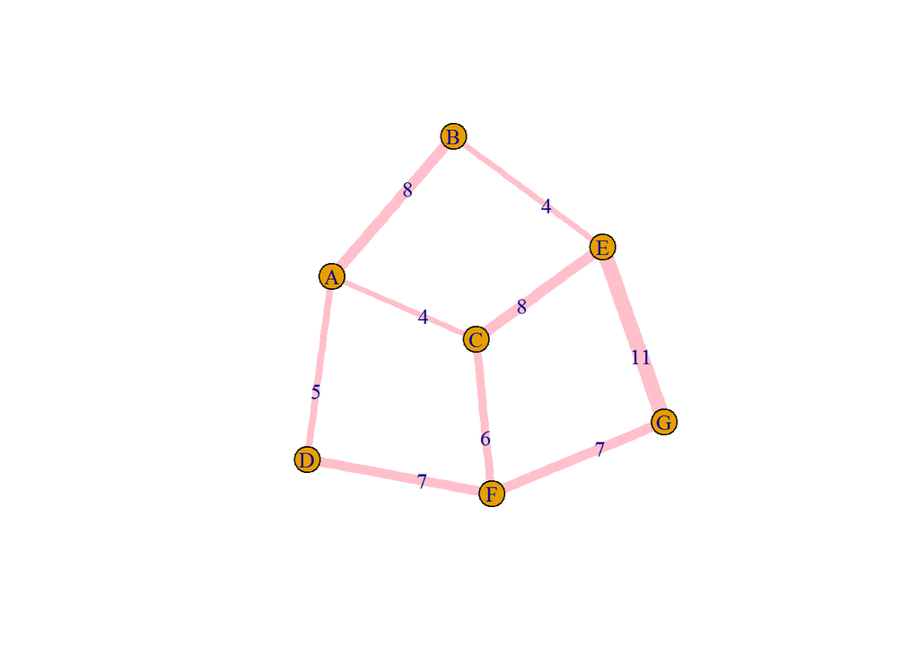

```r
el=read.csv("src/Dataset-Astar-Example-EDGES.csv") # read the 'Dataset-Astar-Example-EDGES.csv' file
heuristics <- el[el$type==" heuristic",]
el1<- el[el$type!=" heuristic",]

gr=graph.data.frame(el1,directed=FALSE)
E(gr)$width <- E(gr)$weight
E(gr)$color <- "pink"
E(gr)$label<- E(gr)$weight

plot(gr)
```

Celem algorytmu będzie znalezienie ścieżki od węzła A do węzła G. Ręczne obliczenia wskazują, że optymalną siężką jest A-C-F-G

## algorytm

Algorytm IDA* opiera się na algorytmie przeszukiwania w głąb (interative deepending depth-first search) wykorzystującym jednocześnie heuterystyki zaimplementwane w algorytmie A*. Takie zastosowanie pozwala na znaczne zredukowanie ilości pamięci potrzebnej do przechowywania dla algorytmu A* jednocześnie wykorzystujac walory heuterystyk.

Algorym można przedstawić jako[1](http://www2.inf.uos.de/papers_html/ai_94/node2.html), [2](https://pdfs.semanticscholar.org/7eaf/535ca7f8d1e920e092483d11efb989982f19.pdf):

*“f(n) - total cost of a node n (cost already spent in reaching that node g(n) plus a lover bound on the estimated cost of the path to a goal staten h(n)). At the begining the cost is set to the heuteristic estimate of the initial state h(root). Then, for each iteration, the bound is increased to the minimum value that exceeded the previosuly bounnd”* [1]:

```
procedure IDA* (n);
bound :=h(n)
while not solved do
  bound:=DFS(n,bound);

function DFS(n, bound);
if f(n) > bound
  then return f(n);
if h(n)=0
  then return solved;
return lowest value of DFS(ni, bound)
       for all successors ni of n
```

funkcje pomocnicze:

```r
h <- function(start, goal){
  val<- heuristics[heuristics$from==start & heuristics$to==goal,"weight"]
  if(!any(val)) return(0)
  else return(as.numeric(val))
}
dist_between <- function(current, neighbor){
  ei<-get.edge.ids(gr, c(current,neighbor))
  val <- E(gr)$weight[ei]
  if(!any(val)) return(NA)
  else return(val)
}
gScore <- as.list(rep(Inf,length(V(gr))))
```

implementacja w R:

```r
IDA_star <-function(root, goal, gr){
  bound = h(root, goal)
  found = F
  g=0.0
  gScore <- as.list(rep(Inf,length(V(gr))))
  names(gScore) <- names(as.list(V(gr)))
  gScore[[root]] <<- 0
  while(found==F){
    print(paste("starting new loop with bound= ",bound))
    #  t := search(root, 0, bound)
    t = DFS(root, g, bound, root, gr, el1, goal)
    # if t = FOUND then return bound
    if(t[[1]]==T){
      return(list(T,t[[2]]))}
    # if t = Inf then return NOT_FOUND
    if(t[[2]]==Inf){return(list(F,0))}
    bound = t[[2]]
    found = t[[1]]
  }

}

  DFS <- function(n, g, bound, ring, graph_, el_, goal){
    # f := g + h(node)
    f = g + h(n, goal)
    print(paste(ring,'f=',f))

    #  if f > bound then return f
    if(f > bound) return(list(F,f))

    # if is_goal(node) then return FOUND
    if(n==goal){
      print(ring)
      return(list(T,gScore[[n]]))
      }
    min= Inf

    # for succ in successors(node) do
    for(neighbor in names(neighbors(graph_, n))){
      if(grepl(neighbor, ring))next

      gScore[[neighbor]] <<- gScore[[n]]+dist_between(n, neighbor)

      ring_tmp = paste(ring,'-',neighbor )
      gi = gScore[[neighbor]]
      print(paste(ring, '?',neighbor , 'g=',gi))
      # t := search(succ, g + cost(node, succ), bound)
      t <- DFS(neighbor, gi, bound, ring_tmp, graph_, el_, goal)
      # if t = FOUND then return FOUND
      if(t[[1]] == T){return(list(T,t[[2]]))}
      # if t < min then min := t
      if (t[[2]]<min){min = t[[2]]}
    }
      return(list(F,min))
  }
```

## test

```r
IDA_star('A', 'G', gr)
```

```
## [1] "starting new loop with bound=  15"
## [1] "A f= 15"
## [1] "A ? B g= 8"
## [1] "A - B f= 20"
## [1] "A ? D g= 5"
## [1] "A - D f= 16"
## [1] "A ? C g= 4"
## [1] "A - C f= 15"
## [1] "A - C ? E g= 12"
## [1] "A - C - E f= 20"
## [1] "A - C ? F g= 10"
## [1] "A - C - F f= 10"
## [1] "A - C - F ? D g= 17"
## [1] "A - C - F - D f= 28"
## [1] "A - C - F ? G g= 17"
```

[output cut: 46 more lines]

```
## [[1]]
## [1] TRUE
##
## [[2]]
## [1] 17
```